# Project: Investing Gapminder Data

- Introduction
- Data Wrangling
- Exploratory Data Analysis
- Conclusions

## Introduction

```python
import numpy as np
import pandas as pd
import matplotlib.pyplot as plt
import seaborn as sns
% matplotlib inline
```

The datasets which I have selected for this exploration are global indicator data taken from Gapminder World. The four indicators I have decided to explore are life expectancy, mean years of schooling, income (GDP per capita), and fertility (number of children per woman).

The questions I hope to answer are as follows:

1. What have been the global trends regarding this four indicators in the past half-century?
2. What are the best predictors of the life expectancy in a country?

## Data Wrangling

### General Properties

```python
life = pd.read_csv('life_expectancy.csv')
meanyears = pd.read_csv('mean_years_school.csv')
income = pd.read_csv('income_per_capita.csv')
fertility = pd.read_csv('children_per_woman.csv')
```

### Data Cleaning

```python
life.head()
```

|  | country | 1800 | 1801 | 1802 | 1803 | 1804 | 1805 | 1806 | 1807 | 1808 | ... | 2009 | 2010 | 2011 | 2012 | 2013 | 2014 | 2015 | 2016 | 2017 | 2018 |
| --- | --- | --- | --- | --- | --- | --- | --- | --- | --- | --- | --- | --- | --- | --- | --- | --- | --- | --- | --- | --- | --- |
| 0 | Afghanistan | 28.2 | 28.2 | 28.2 | 28.2 | 28.2 | 28.2 | 28.1 | 28.1 | 28.1 | ... | 55.7 | 56.2 | 56.7 | 57.2 | 57.7 | 57.8 | 57.9 | 58.0 | 58.4 | 58.7 |
| 1 | Albania | 35.4 | 35.4 | 35.4 | 35.4 | 35.4 | 35.4 | 35.4 | 35.4 | 35.4 | ... | 75.9 | 76.3 | 76.7 | 77.0 | 77.2 | 77.4 | 77.6 | 77.7 | 77.9 | 78.0 |
| 2 | Algeria | 28.8 | 28.8 | 28.8 | 28.8 | 28.8 | 28.8 | 28.8 | 28.8 | 28.8 | ... | 76.3 | 76.5 | 76.7 | 76.8 | 77.0 | 77.1 | 77.3 | 77.4 | 77.6 | 77.9 |
| 3 | Andorra | NaN | NaN | NaN | NaN | NaN | NaN | NaN | NaN | NaN | ... | 82.7 | 82.7 | 82.6 | 82.6 | 82.6 | 82.6 | 82.5 | 82.5 | NaN | NaN |
| 4 | Angola | 27.0 | 27.0 | 27.0 | 27.0 | 27.0 | 27.0 | 27.0 | 27.0 | 27.0 | ... | 59.3 | 60.1 | 60.9 | 61.7 | 62.5 | 63.3 | 64.0 | 64.7 | 64.9 | 65.2 |

5 rows × 220 columns

```python
life.info()
```

```
<class 'pandas.core.frame.DataFrame'>
RangeIndex: 187 entries, 0 to 186
Columns: 220 entries, country to 2018
dtypes: float64(219), object(1)
memory usage: 321.5+ KB
```

```python
income.head()
```

|  | country | 1800 | 1801 | 1802 | 1803 | 1804 | 1805 | 1806 | 1807 | 1808 | ... | 2031 | 2032 | 2033 | 2034 | 2035 | 2036 | 2037 | 2038 | 2039 | 2040 |
| --- | --- | --- | --- | --- | --- | --- | --- | --- | --- | --- | --- | --- | --- | --- | --- | --- | --- | --- | --- | --- | --- |
| 0 | Afghanistan | 603 | 603 | 603 | 603 | 603 | 603 | 603 | 603 | 603 | ... | 2420 | 2470 | 2520 | 2580 | 2640 | 2700 | 2760 | 2820 | 2880 | 2940 |
| 1 | Albania | 667 | 667 | 667 | 667 | 667 | 668 | 668 | 668 | 668 | ... | 18500 | 18900 | 19300 | 19700 | 20200 | 20600 | 21100 | 21500 | 22000 | 22500 |
| 2 | Algeria | 715 | 716 | 717 | 718 | 719 | 720 | 721 | 722 | 723 | ... | 15600 | 15900 | 16300 | 16700 | 17000 | 17400 | 17800 | 18200 | 18600 | 19000 |
| 3 | Andorra | 1200 | 1200 | 1200 | 1200 | 1210 | 1210 | 1210 | 1210 | 1220 | ... | 73200 | 74800 | 76400 | 78100 | 79900 | 81600 | 83400 | 85300 | 87200 | 89100 |
| 4 | Angola | 618 | 620 | 623 | 626 | 628 | 631 | 634 | 637 | 640 | ... | 6270 | 6410 | 6550 | 6700 | 6850 | 7000 | 7150 | 7310 | 7470 | 7640 |

5 rows × 242 columns

```python
income.info()
```

```
<class 'pandas.core.frame.DataFrame'>
RangeIndex: 193 entries, 0 to 192
Columns: 242 entries, country to 2040
dtypes: int64(241), object(1)
memory usage: 365.0+ KB
```

```python
meanyears.head()
```

|  | country | 1970 | 1971 | 1972 | 1973 | 1974 | 1975 | 1976 | 1977 | 1978 | ... | 2006 | 2007 | 2008 | 2009 | 2010 | 2011 | 2012 | 2013 | 2014 | 2015 |
| --- | --- | --- | --- | --- | --- | --- | --- | --- | --- | --- | --- | --- | --- | --- | --- | --- | --- | --- | --- | --- | --- |
| 0 | Afghanistan | 1.82 | 1.87 | 1.92 | 1.97 | 2.02 | 2.07 | 2.12 | 2.17 | 2.23 | ... | 4.33 | 4.43 | 4.53 | 4.63 | 4.73 | 4.84 | 4.94 | 5.05 | 5.16 | 5.27 |
| 1 | Albania | 5.47 | 5.58 | 5.69 | 5.80 | 5.91 | 6.02 | 6.13 | 6.24 | 6.36 | ... | 9.89 | 10.00 | 10.20 | 10.30 | 10.40 | 10.60 | 10.70 | 10.90 | 11.00 | 11.20 |
| 2 | Algeria | 2.77 | 2.86 | 2.95 | 3.04 | 3.14 | 3.25 | 3.35 | 3.46 | 3.58 | ... | 8.13 | 8.28 | 8.42 | 8.57 | 8.71 | 8.85 | 8.99 | 9.14 | 9.28 | 9.42 |
| 3 | Andorra | 9.16 | 9.30 | 9.44 | 9.58 | 9.72 | 9.86 | 10.00 | 10.10 | 10.30 | ... | 13.90 | 14.10 | 14.20 | 14.30 | 14.40 | 14.50 | 14.60 | 14.70 | 14.80 | 14.90 |
| 4 | Angola | 2.25 | 2.31 | 2.36 | 2.42 | 2.48 | 2.54 | 2.60 | 2.67 | 2.73 | ... | 5.10 | 5.21 | 5.32 | 5.43 | 5.55 | 5.66 | 5.78 | 5.90 | 6.02 | 6.14 |

5 rows × 47 columns

```python
meanyears.info(False)
```

```
<class 'pandas.core.frame.DataFrame'>
RangeIndex: 187 entries, 0 to 186
Columns: 47 entries, country to 2015
dtypes: float64(46), object(1)
memory usage: 68.7+ KB
```

```python
fertility.head()
```

|  | country | 1800 | 1801 | 1802 | 1803 | 1804 | 1805 | 1806 | 1807 | 1808 | ... | 2009 | 2010 | 2011 | 2012 | 2013 | 2014 | 2015 | 2016 | 2017 | 2018 |
| --- | --- | --- | --- | --- | --- | --- | --- | --- | --- | --- | --- | --- | --- | --- | --- | --- | --- | --- | --- | --- | --- |
| 0 | Afghanistan | 7.00 | 7.00 | 7.00 | 7.00 | 7.00 | 7.00 | 7.00 | 7.00 | 7.00 | ... | 6.04 | 5.82 | 5.60 | 5.38 | 5.17 | 4.98 | 4.80 | 4.64 | 4.48 | 4.33 |
| 1 | Albania | 4.60 | 4.60 | 4.60 | 4.60 | 4.60 | 4.60 | 4.60 | 4.60 | 4.60 | ... | 1.65 | 1.65 | 1.67 | 1.69 | 1.70 | 1.71 | 1.71 | 1.71 | 1.71 | 1.71 |
| 2 | Algeria | 6.99 | 6.99 | 6.99 | 6.99 | 6.99 | 6.99 | 6.99 | 6.99 | 6.99 | ... | 2.83 | 2.89 | 2.93 | 2.94 | 2.92 | 2.89 | 2.84 | 2.78 | 2.71 | 2.64 |
| 3 | Angola | 6.93 | 6.93 | 6.93 | 6.93 | 6.93 | 6.93 | 6.93 | 6.94 | 6.94 | ... | 6.24 | 6.16 | 6.08 | 6.00 | 5.92 | 5.84 | 5.77 | 5.69 | 5.62 | 5.55 |
| 4 | Antigua and Barbuda | 5.00 | 5.00 | 4.99 | 4.99 | 4.99 | 4.98 | 4.98 | 4.97 | 4.97 | ... | 2.15 | 2.13 | 2.12 | 2.10 | 2.09 | 2.08 | 2.06 | 2.05 | 2.04 | 2.03 |

5 rows × 220 columns

```python
fertility.info()
```

```
<class 'pandas.core.frame.DataFrame'>
RangeIndex: 184 entries, 0 to 183
Columns: 220 entries, country to 2018
dtypes: float64(219), object(1)
memory usage: 316.3+ KB
```

From looking at the overview of the data, it appears that the data does not require a lot of cleaning. Interestingly, the income data goes beyond the current year, for predictions up to the year 2040. I plan on using only the most recent year available in all the datasets, which is 2015.

The datasets also have a different number of countries (based on the number of entries). It would be useful here to create a separate, combined dataframe which contains all the indicator data, which will be useful for answering the second research question.

```python
combined = life[['country', '2015']].merge(income[['country', '2015']], how = 'inner', on = 'country')
combined = combined.merge(fertility[['country', '2015']], how = 'inner', on = 'country')
combined = combined.merge(meanyears[['country', '2015']], how = 'inner', on = 'country')
```

I create a new combined dataframe using the 2015 data for each indicator. By using an inner merge on the data, I ensure that only countries that have data for all four indicators remain in the combined dataset. I then proceed to rename the columns in the combined dataframe to match the indicator, and I set the index to the country name.

```python
combined.columns = ['country','life_expectancy', 'income', 'fertility', 'schooling']
combined.set_index('country', inplace = True)
combined.head()
```

| country | life_expectancy | income | fertility | schooling |
| --- | --- | --- | --- | --- |
| Afghanistan | 57.9 | 1750 | 4.80 | 5.27 |
| Albania | 77.6 | 11000 | 1.71 | 11.20 |
| Algeria | 77.3 | 13700 | 2.84 | 9.42 |
| Angola | 64.0 | 6230 | 5.77 | 6.14 |
| Antigua and Barbuda | 77.2 | 20100 | 2.06 | 13.50 |

```python
fertilitybins = [0,1,2,3,4,5, 6, 10]
fertilitylabels = ['<1', '1-2', '2-3', '3-4', '4-5', '5-6', '6+']
combined['fertility_class'] = pd.cut(combined['fertility'], fertilitybins, labels = fertilitylabels)
```

```python
schoolingbins = [0,5,10, 20]
schoolinglabels = ['<5', '5-10', '10+']
combined['schooling_class'] = pd.cut(combined['schooling'], schoolingbins, labels = schoolinglabels)
```

```python
incomebins = [0,20000,40000,60000,80000,100000, 120000]
incomelabels = ['<20000', '20000-40000', '40000-60000', '60000-80000', '80000-100000', '100000-120000']
combined['income_class'] = pd.cut(combined['income'], incomebins, labels = incomelabels)
```

```python
combined.head()
```

[output not shown]

I've created a new column for each indicator, which separates the continuous data into discrete, categorical bins. This will make it easier to visualise the data later on in the process.

## Exploratory Data Analysis

Now that we have all the data in a usable manner, let us do some exploration to answer our two research questions. As a reminder, the questions we are hoping to answer are as follows:

1. What have been the global trends regarding this four indicators in the past half-century?
2. What are the best predictors of the life expectancy in a country?

### Research Question 1 - What have been the global trends regarding this four indicators in the past half-century?

```python
life.set_index('country', inplace = True)
```

```
(0, 218)
```

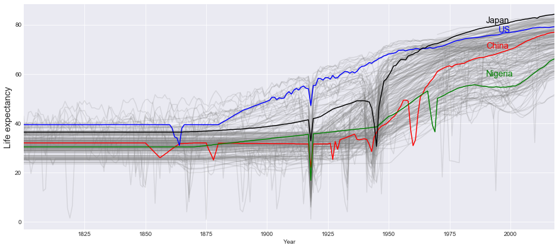

```python
plt.figure(figsize = (16,7))
plt.style.use('seaborn-darkgrid')
plt.xlabel('Year')
plt.ylabel('Life expectancy', fontsize = 15)
plt.xticks([25, 50, 75, 100, 125, 150, 175, 200])
for each in life.index.values:
    plt.plot(life.loc[each], color = 'grey', alpha = 0.2)

plt.plot(life.loc['China'], color = 'red')
plt.text(190, life.loc['China']['2015'] - 6, 'China', color = 'red', size = 'x-large')

plt.plot(life.loc['United States'], color = 'blue')
plt.text(195, life.loc['United States']['2015'] - 2, 'US', color = 'blue', size = 'x-large')

plt.plot(life.loc['Nigeria'], color = 'green')
plt.text(190, life.loc['Nigeria']['2015'] - 5, 'Nigeria', color = 'green', size = 'x-large')

plt.plot(life.loc['Japan'], color = 'black')
plt.text(190, life.loc['Japan']['2015'] - 3, 'Japan', color = 'black', size = 'x-large')


plt.xlim(0, 218)
```

This is a time series plot of every single country's life expectancy from the year 1800 to 2018. I have also specifically highlighted several countries to see how the trends for developed/developing countries diverge.

The most interesting aspect about this graph is that there are often global phenomenae which affect the life expectancies in all countries simultaneously. The most jarring examples of this would be around 1919 and 1945, at the height of the two World Wars, during which millions of casualties led to a marked decline in life expectancies. Specifically in the case of China, we also see the effects of the cultural revolution in the 1960s, which led to a precipitous dip in life expectancies, which appears to be of greater magnitude than even the dips caused by the world war.

But it is also encouraging to see that at the turn of the century, as almost a general rule, every country has seen marked increases in their life expectancy, as a result of improved technology and healthcare. At the start of the century, most countries had a life expectancy in the range of 30 to 50 years, whereas now the range falls between 60 and 80 years; almost a doubling within the span of 100 years.

```python
meanyears.set_index('country', inplace = True)
```

```
(0, 45)
```

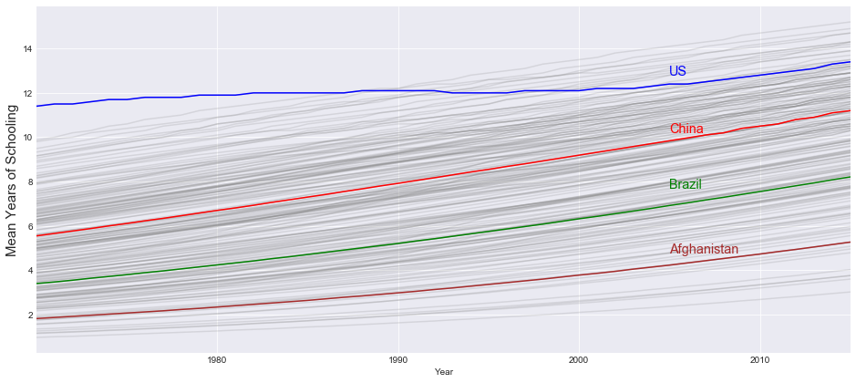

```python
plt.figure(figsize = (16,7))
plt.style.use('seaborn-darkgrid')
plt.xlabel('Year')
plt.ylabel('Mean Years of Schooling', fontsize = 15)
plt.xticks([10, 20, 30, 40])
for each in meanyears.index.values:
    plt.plot(meanyears.loc[each], color = 'grey', alpha = 0.2)

plt.plot(meanyears.loc['China'], color = 'red')
plt.text(35, meanyears.loc['China']['2015']-1, 'China', color = 'red', size = 'x-large')

plt.plot(meanyears.loc['United States'], color = 'blue')
plt.text(35, meanyears.loc['United States']['2015']-0.6, 'US', color = 'blue', size = 'x-large')

plt.plot(meanyears.loc['Brazil'], color = 'green')
plt.text(35, meanyears.loc['Brazil']['2015']-0.5, 'Brazil', color = 'green', size = 'x-large')

plt.plot(meanyears.loc['Afghanistan'], color = 'brown')
plt.text(35, meanyears.loc['Afghanistan']['2015']-0.5, 'Afghanistan', color = 'brown', size = 'x-large')

plt.xlim(0, 45)
```

This is a similar graph, except it depicts the trends in the average years of schooling in each country. I have against highlighted several countries to see their particular growths. It should be noted that the data available for this indicator only begins in the year 1970.

What is extremely interesting about this graph is that the trend is practically universal: every country has seen increasing literacy rates since the 1970, and even the rate of increase is pretty consistent across the globe. The only real exception would be the United States, which has maintained a high rate of literacy for each of the past four decades, without much variation.

```python
income.set_index('country', inplace = True)
```

```
(0, 218)
```

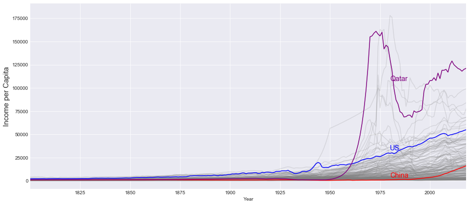

```python
plt.figure(figsize = (16, 7))

for each in income.index.values:
    plt.plot(income.loc[each], color = 'grey', alpha = 0.2)

plt.plot(income.loc['China'], color = 'red', alpha = 1)
plt.text(180, income.loc['China']['2000'], 'China', color = 'red', size = 'x-large')

plt.plot(income.loc['United States'], color = 'blue', alpha = 1)
plt.text(180, income.loc['United States']['1985'], 'US', color = 'blue', size = 'x-large')

plt.plot(income.loc['Qatar'], color = 'purple', alpha = 1)
plt.text(180, income.loc['Qatar']['2000'], 'Qatar', color = 'purple', size = 'x-large')

plt.xlabel('Year')
plt.ylabel('Income per Capita', fontsize = 15)
plt.xticks([25, 50, 75, 100, 125, 150, 175, 200])

plt.xlim(0, 218)
```

This is a another time-series graph, depicting the trends in the income per capita in each country. I have highlighted several countries to see their trends. The data for this indicator spans the years 1800 - 2018.

It is suprising that despite all that's been made about China's burgeoning economy in the recent decades, its income per capita remains relatively low. Ultimately, it still has a lot of catching up to do to truly be in the same economic league as it's first-world peers.

```python
fertility.set_index('country', inplace = True)
```

```
(0, 218)
```

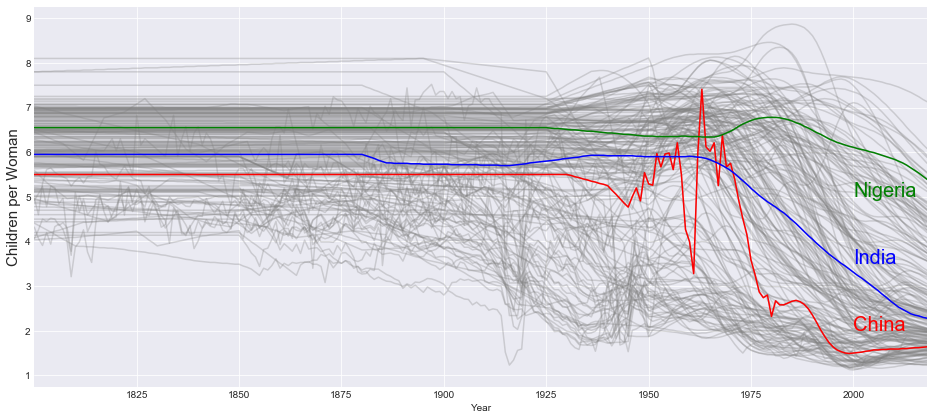

```python
plt.figure(figsize = (16, 7))

for each in fertility.index.values:
    plt.plot(fertility.loc[each], color = 'grey', alpha = 0.3)

plt.plot(fertility.loc['China'], color = 'red', alpha = 1)
plt.text(200, 2, 'China', fontsize = 20, color = 'red')

plt.plot(fertility.loc['India'], color = 'blue', alpha = 1)
plt.text(200, 3.5, 'India', fontsize = 20, color = 'blue')

plt.plot(fertility.loc['Nigeria'], color = 'green', alpha = 1)
plt.text(200, 5, 'Nigeria', fontsize = 20, color = 'green')

plt.xlabel('Year')
plt.ylabel('Children per Woman', fontsize = 15)
plt.xticks([25, 50, 75, 100, 125, 150, 175, 200])


plt.xlim(0, 218)
```

Lastly, this is a another time-series graph, depicting the trends in average children per woman in each country. I have highlighted several countries to see their trends. The data for this indicator spans the years 1800 - 2018.

The variation in fertility across countries is really quite substantial. Even in the modern day, there are countries with a fertility rate of over 6 children per woman. But overall, there is still a clear downward trend.

### Research Question 2 - What are the best predictors of the life expectancy in a country?

It is time to look at the correlations between the individual indicators. We will be using the 'combined' data frame, which has the 2015 data for each country for each indicator.

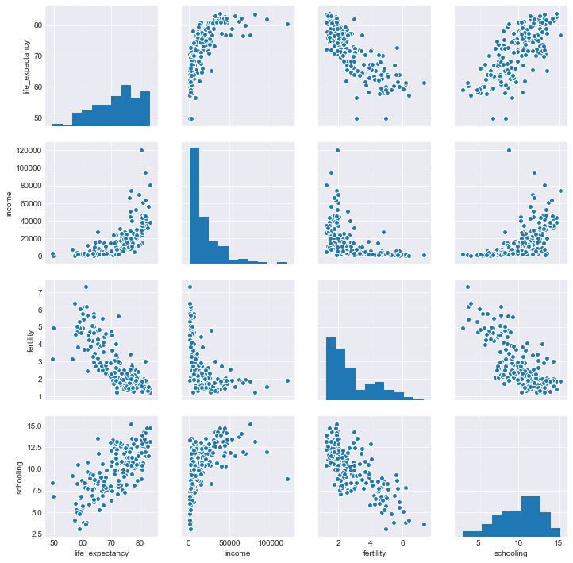

```python
sns.pairplot(combined)
```

At first glance, it seems that there is quite a strong correlation amongst all of the indicators. Fertility and schooling appearing to have a strong linear relationship, whilst income and life expectancy appears to have more of a logarithmic relationship. Life expectancy and fertility also exhibits some degree of linear relationship.

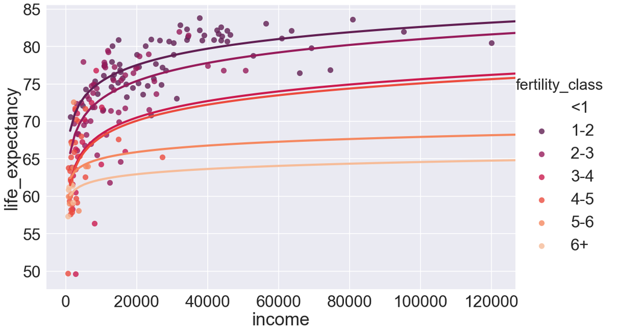

```python
sns.set_style('darkgrid')
sns.set_context('poster', font_scale = 2)
sns.lmplot(x = 'income', size = 10, aspect = 1.5, ci = None, y = 'life_expectancy', data = combined, logx =True, hue = 'fertility_class',  palette = 'rocket');
```

This is a graph of income per capita against life expectancy of all countries in 2015. The hue represents the fertility class of the data points. The trend is surprisingly clear: countries with a lower fertility rate consistently have higher rates of life expectancies, and countries with a higher income per capita also have a higher life expectancy. The relationship appears to be logarithmic.

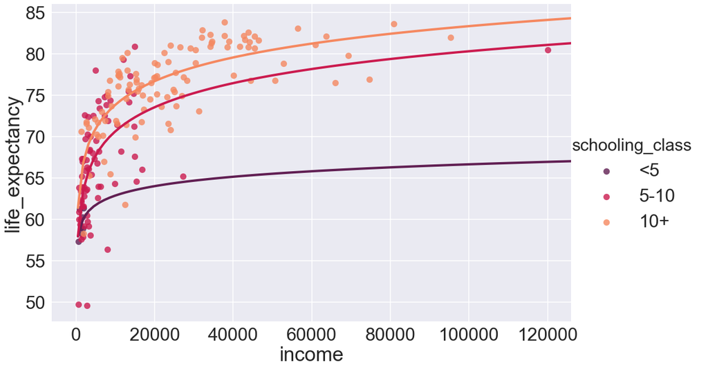

```python
sns.set_style('darkgrid')
sns.set_context('poster', font_scale = 2)
sns.lmplot(x = 'income', size = 10, aspect = 1.5, ci = None, y = 'life_expectancy', data = combined, logx =True, hue = 'schooling_class', palette = 'rocket')
```

This is the same as the previous graph, except the hue represents the mean years of schooling in the country. Again, there is a clear trend, where more mean years of schooling consistently predicts a higher life expectancy in the country.

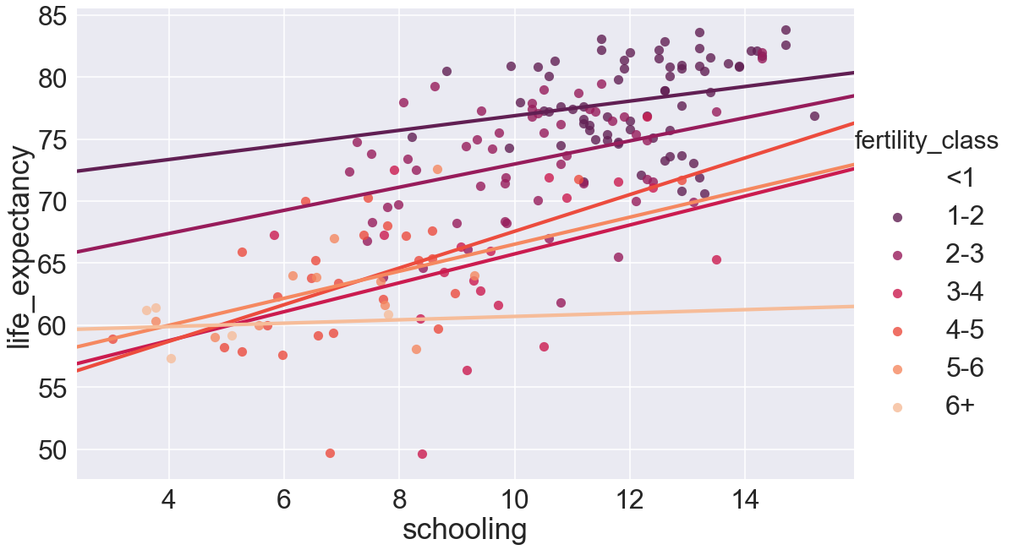

```python
sns.set_style('darkgrid')
sns.set_context('poster', font_scale = 2)
sns.lmplot(x = 'schooling', size = 10, aspect = 1.5, ci = None, y = 'life_expectancy', data = combined, hue = 'fertility_class', palette = 'rocket')
```

Lastly, this graph depicts schooling against life expectancy. The data on this appears to have a weaker correlation, although there is still an indication of a positive linear relationship. Higher mean years of schooling generally predicts a longer life expectancy

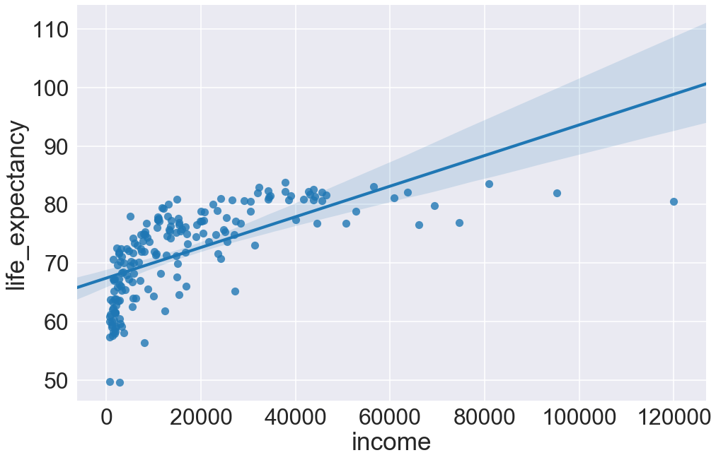

```python
sns.set_style('darkgrid')
sns.set_context('poster', font_scale = 2)
sns.lmplot(x = 'income', size = 10, aspect = 1.5, y = 'life_expectancy', data = combined, palette = 'rocket')
```

I wanted to take a closer look at the relationship between income and life expectancy. It appears that the relationship is logarithmic rather than linear. It would thus probably be more illustrative if we adjusted the axes to account for this relationship.

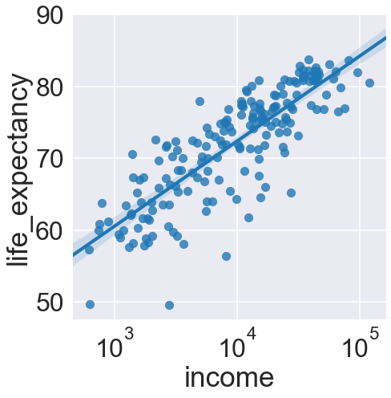

```python
f, ax = plt.subplots(figsize=(7, 7))
ax.set(xscale="log")
sns.regplot('income', "life_expectancy", data = combined, ax=ax, logx = True)
```

```python
from scipy import stats
```

```
array([ 5.15275895, 24.93425615])
```

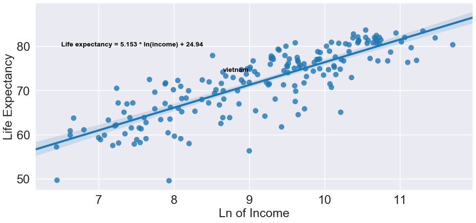

```python
combined['log_income'] = np.log(combined['income'])
f, ax = plt.subplots(figsize=(16, 7))

sns.set_context(rc = {'font.size': 20, 'axes.labelsize': 25, 'xtick.labelsize': 25, 'ytick.labelsize': 25})
fig = sns.regplot('log_income', "life_expectancy", data = combined, ax=ax)
fig.text(8.65, 74.3, "vietnam", horizontalalignment='left', size='x-small', color='black', weight='semibold')
fig.text(6.5, 80, "Life expectancy = 5.153 * ln(income) + 24.94", horizontalalignment='left', size='x-small', color='black', weight='semibold')
ax.set_xlabel('Ln of Income')
ax.set_ylabel('Life Expectancy')
np.polyfit(combined['log_income'], combined['life_expectancy'], 1)
```

y = 5.15log(x) + 24.94

The equation is as follows: y = 5.15log(x) + 24.94

This would suggest that the life expectancy for a given country is the natural logarithm of the income per capita, multiplied by 5.153, plus 24.94.

## Conclusions

Ultimately, the data provided here at most suggests a series of correlations, but does not say anything about the causation between the variables.

What I have found in this exploration is that:

- There is a linear relationship between fertility and life expectancy
- There is a linear relationship between mean years of schooling and life expectancy
- There is a logarithmic relationship between income per capita and life expectancy, which can be described by the equation y = 5.15log(x) + 24.94